# Assignment 2

Niall ONeill

15 de febrero de 2019

# Dynamic Models for Prediction

## Exercise 1

**Data set books contains the daily sales of paperback and hardcover books at the same store. The task is to forecast the next four days’ sales for paperback books (data set books).**

1. Plot the series and discuss the main features of the data.
2. Use simple exponential smoothing with the ses function (setting initial=simple) and explore different values of $\alpha$ for the paperback series. Record the within-sample SSE for the one-step forecasts. Plot SSE against $\alpha$ and find which value of $\alpha$ works best. What is the effect of $\alpha$ on the forecasts?
3. Now let ses select the optimal value of $\alpha$. Use this value to generate forecasts for the next four days. Compare your results with (b).

We load in the datasets and the relevant libraries:

```r
library(fpp)
```

1. We can plot the dataset with:

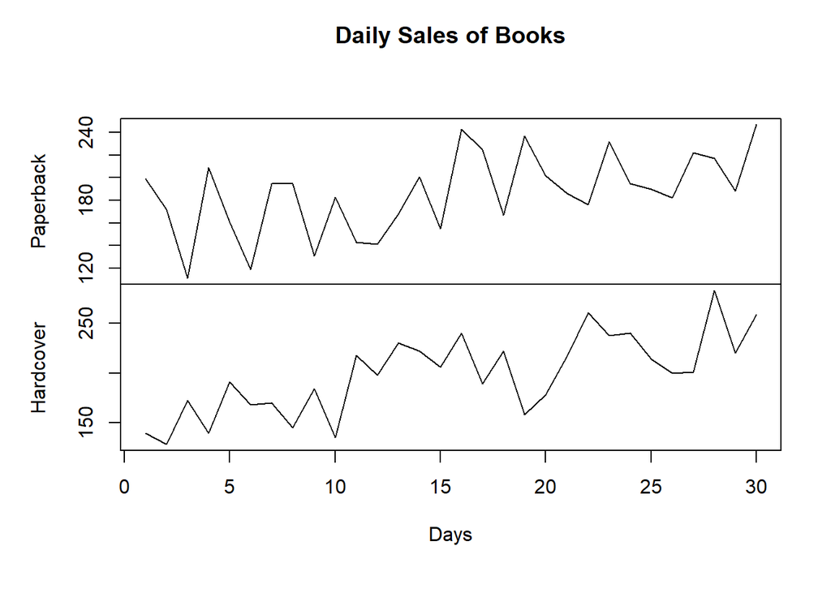

```r
plot(books, ylab= "Number of Sales", xlab="Days", main="Daily Sales of Books")
```

For both the paperback and the hardcover data there is a positive trend. In addition it appears that the data may be cyclical but it doesn’t appear to have a regular seasonality.

2. We can calculate the SES for one-step forecast and the SSE using different values of alpha using:

```r
fit1 <- ses(books[,1], alpha = 0.2, initial = "simple", h = 4)
sse1 <- sum(books[,1] - fitted(fit1))
fit2 <- ses(books[,1], alpha = 0.3, initial = "simple", h = 4)
sse2 <- sum(books[,1] - fitted(fit2))
fit3 <- ses(books[,1], alpha = 0.4, initial = "simple", h = 4)
sse3 <- sum(books[,1] - fitted(fit3))
fit4 <- ses(books[,1], alpha = 0.5, initial = "simple", h = 4)
sse4 <- sum(books[,1] - fitted(fit4))
fit5 <- ses(books[,1], alpha = 0.6, initial = "simple", h = 4)
sse5 <- sum(books[,1] - fitted(fit5))
fit6 <- ses(books[,1], alpha = 0.7, initial = "simple", h = 4)
sse6 <- sum(books[,1] - fitted(fit6))
fit7 <- ses(books[,1], alpha = 0.8, initial = "simple", h = 4)
sse7 <- sum(books[,1] - fitted(fit7))
fit8 <- ses(books[,1], alpha = 0.9, initial = "simple", h = 4)
sse8 <- sum(books[,1] - fitted(fit8))
fitMin <-ses(books[,1], alpha = 0.75, initial = "simple", h = 4)
sseMin <- sum(books[,1] - fitted(fitMin))
```

We can then plot the SSE against the values for alpha:

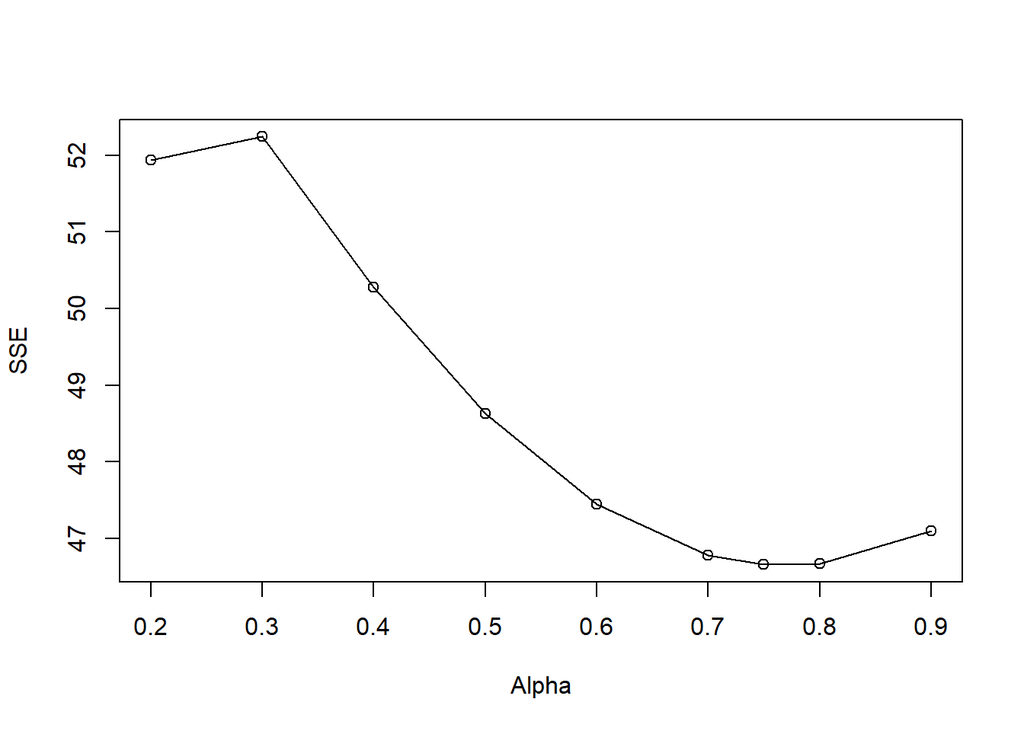

```r
alpha <- c(0.2,0.3,0.4,0.5,0.6,0.7,0.75,0.8,0.9)
sse <- c(sse1,sse2,sse3,sse4,sse5,sse6,sseMin,sse7,sse8)

 plot(alpha,sse, ylab="SSE", xlab = "Alpha",type = "o" )
```

3. To generate a fit for the data using ses with an optimal value of alpha we use:

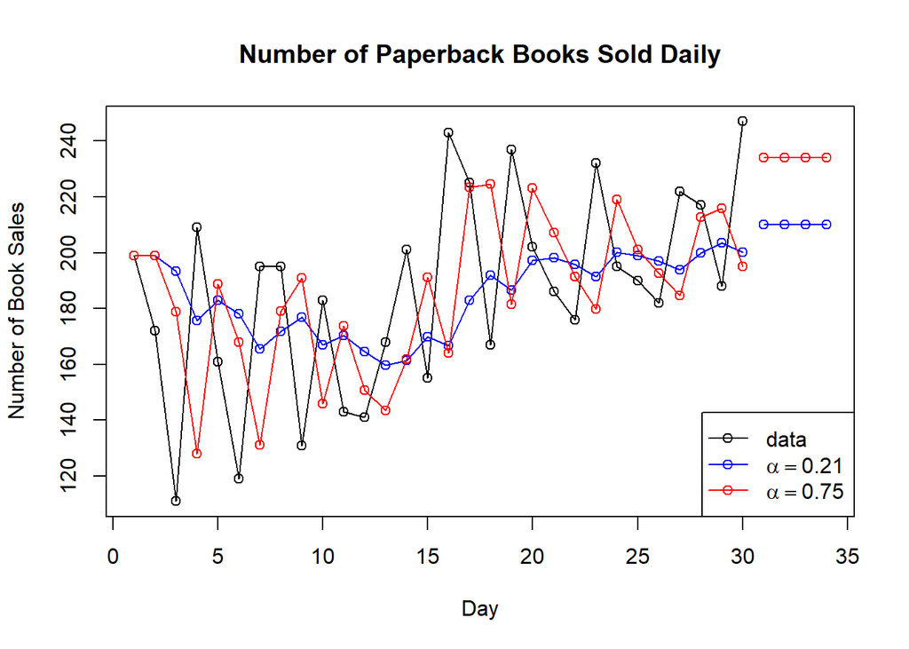

```r
fitOpt <- ses(books[,1], initial = "simple", h = 4)

plot(fitOpt, PI=FALSE, ylab="Number of Book Sales",
     xlab="Day", main ="Number of Paperback Books Sold Daily", fcol="white", type="o")

lines(fitOpt$fitted, col="blue", type="o")
lines(fitMin$fitted, col="red", type="o")

lines(fitOpt$mean, col="blue", type="o")
lines(fitMin$mean, col="red", type="o")

legend("bottomright",lty=1, col=c(1,"blue","red"), c("data", expression(alpha == 0.21), expression(alpha == 0.75)),pch=1)
```

The optimal value of alpha makes more conservative predictions and does not appear to fit the data as well as the best alpha value that we calcaulated in part (b)

## Exercise 2

**Use the monthly Australian short-term overseas visitors data, May 1985-April 2005. (Data set visitors)**

1. Make a time plot of your data and describe the main features of the series.
2. Forecast the next two years using Holt-Winters’ multiplicative method.
3. Why is multiplicative seasonality necessary here?
4. Experiment with making the trend exponential and/or damped.
5. Now fit each of the following models to the same data:
1. an ETS model
2. an additive ETS model applied to a Box-Cox transformed series
3. an STL decomposition applied to the Box-Cox transformed data followed by an ETS model applied to the seasonally adjusted (transformed) data. Plot all the forecasts together.
7. For each model, look at the residual diagnostics and compare the forecasts for the next two years. Which do you prefer?
8. The data is plotted with:

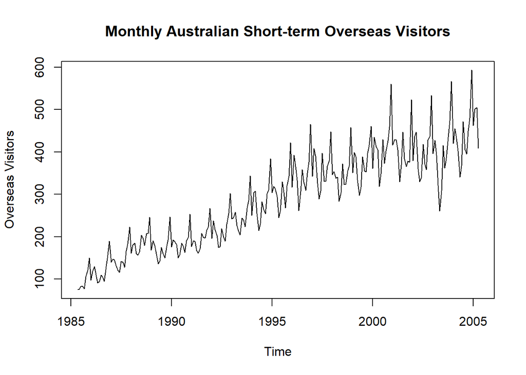

```r
plot(visitors, xlab = "Time", ylab = "Overseas Visitors", main = "Monthly Australian Short-term Overseas Visitors")
```

Looking at the graph it has an upward trend and apprears to have a seasonality and the variance of the data increases with time

```r
fit <-  hw(visitors,seasonal="multiplicative", h=24)
```

3. Multiplicative seasonality is needed here as the variance in the dataset changes with time
4. We can calculate the damped/exponential forecasts with:

```r
fitDamped <- hw(visitors, seasonal='multiplicative', h=24, damped=TRUE)
fitExp <- hw(visitors,seasonal='multiplicative', h=24, exponential=TRUE)
```

(e)(1) We can fit and ETS model to the data using:

```r
fitEts <- ets(visitors)
```

2. A Box-Cox transformation is applied to the data and then an additive ETS is applied:

```r
lambda <- BoxCox.lambda(visitors) #Gather Lambda
boxCox <- BoxCox(visitors,lambda) #Apply Box-Cox transform
fitBoxCoxEts <- ets(boxCox, model = "AAZ")
```

3. Get an STL decomposition of the Box-Cox transformed data, then apply an ETS model to the seasonal data:

```r
stl <- decompose(boxCox) #Decompose the box-cox data
seasonalData <- stl$seasonal #take the seasonal portion
fitSeasonalETS <- ets(seasonalData)
```

7. We look at the residuals diagnostics for each of the fits. Firstly the Holts-Winters Multiplicative method:

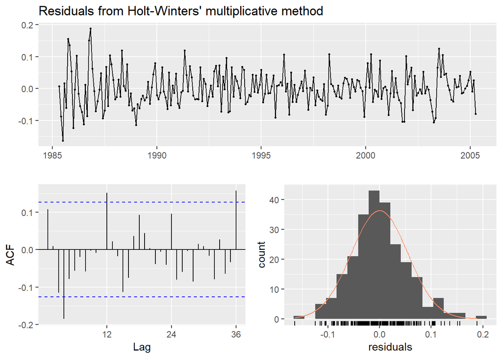

```
##
##  Ljung-Box test
##
## data:  Residuals from Holt-Winters' multiplicative method
## Q* = 35.143, df = 8, p-value = 2.518e-05
##
## Model df: 16.   Total lags used: 24
```

```r
checkresiduals(fit)
```

Next the Damped Method:

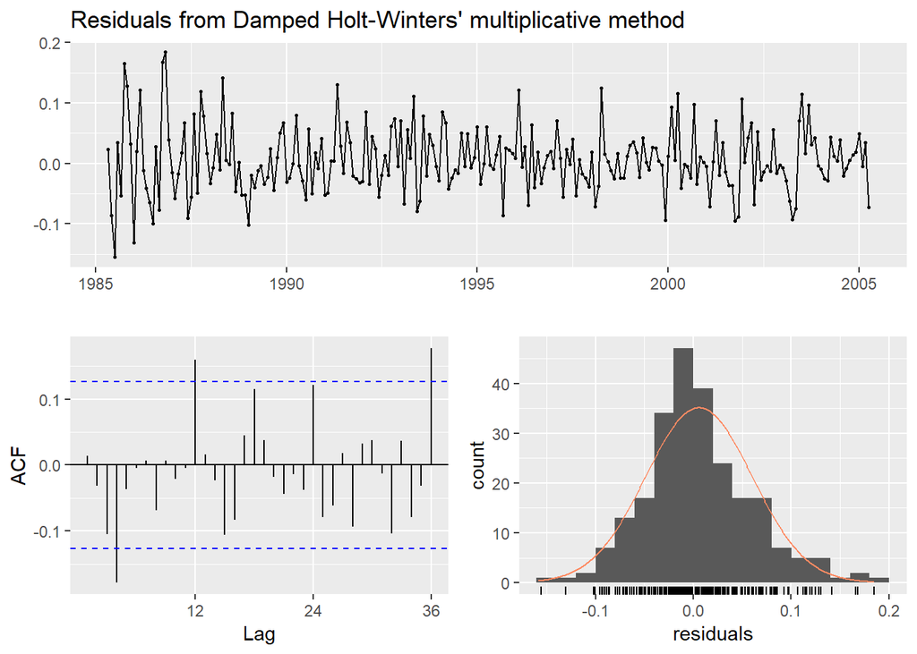

```
##
##  Ljung-Box test
##
## data:  Residuals from Damped Holt-Winters' multiplicative method
## Q* = 33.146, df = 7, p-value = 2.487e-05
##
## Model df: 17.   Total lags used: 24
```

```r
checkresiduals(fitDamped)
```

The Exponential Case:

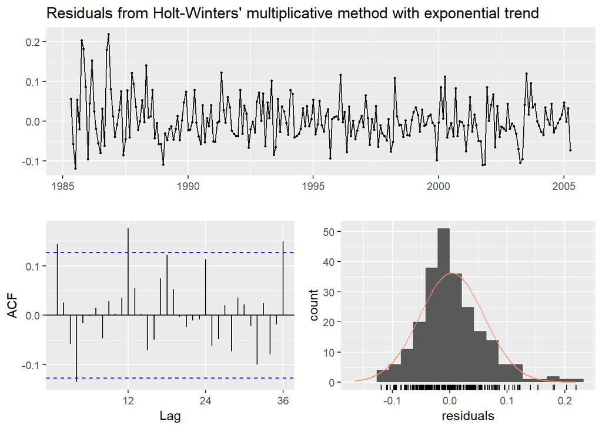

```
##
##  Ljung-Box test
##
## data:  Residuals from Holt-Winters' multiplicative method with exponential trend
## Q* = 31.998, df = 8, p-value = 9.324e-05
##
## Model df: 16.   Total lags used: 24
```

```r
checkresiduals(fitExp)
```

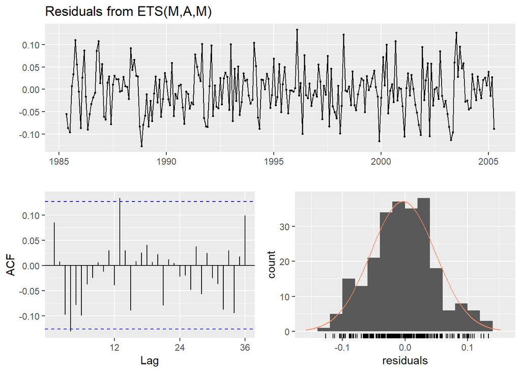

```
##
##  Ljung-Box test
##
## data:  Residuals from ETS(M,A,M)
## Q* = 22.938, df = 8, p-value = 0.003444
##
## Model df: 16.   Total lags used: 24
```

```r
checkresiduals(fitEts)
```

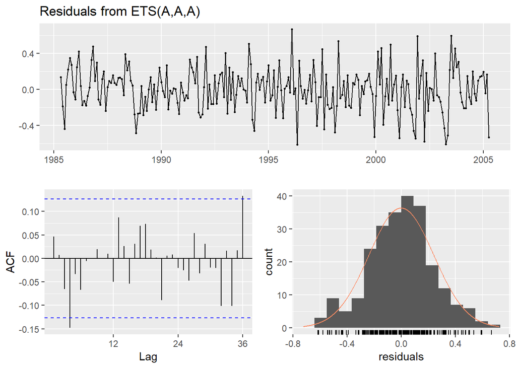

```
##
##  Ljung-Box test
##
## data:  Residuals from ETS(A,A,A)
## Q* = 17.189, df = 8, p-value = 0.0282
##
## Model df: 16.   Total lags used: 24
```

```r
checkresiduals(fitBoxCoxEts)
```

In the case of Box-Cox transformed ETS model the variance of the residuals appear to increase with time

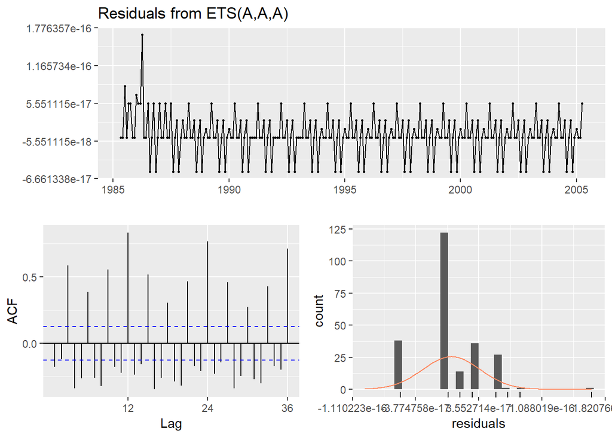

```
##
##  Ljung-Box test
##
## data:  Residuals from ETS(A,A,A)
## Q* = 939.3, df = 8, p-value < 2.2e-16
##
## Model df: 16.   Total lags used: 24
```

```r
checkresiduals(fitSeasonalETS)
```

In this case the residuals do not appear to be normally distributed and a lot of the ACF values lie outside the dashed blue lines

We can then take a look at the forecasts for the fits for the next two years.

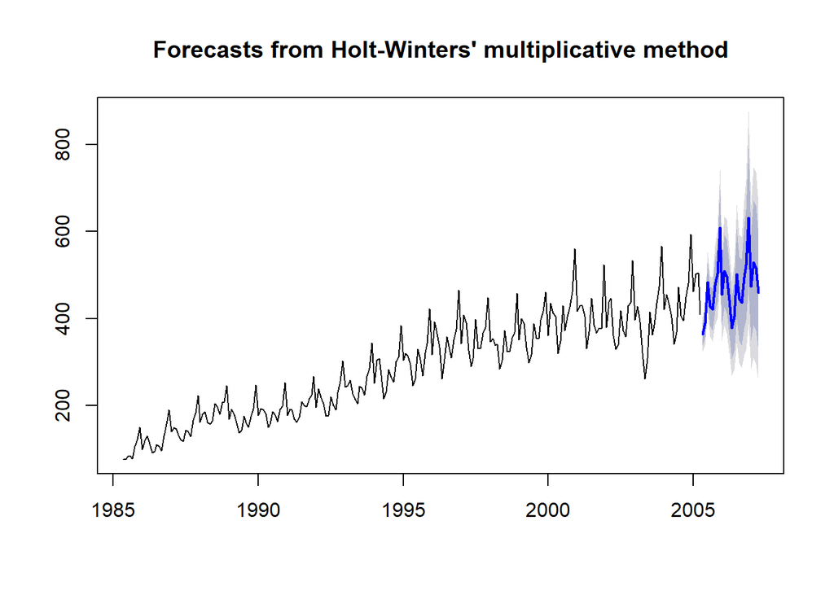

```r
plot(forecast(fit, h=24))
```

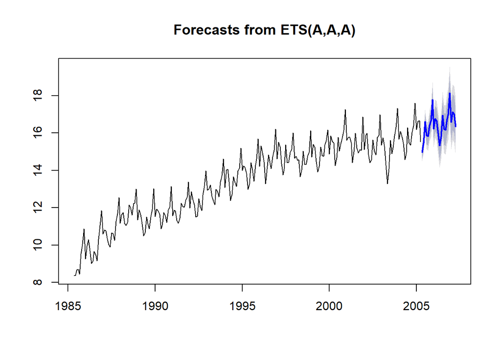

```r
plot(forecast(fitBoxCoxEts, h=24))
```

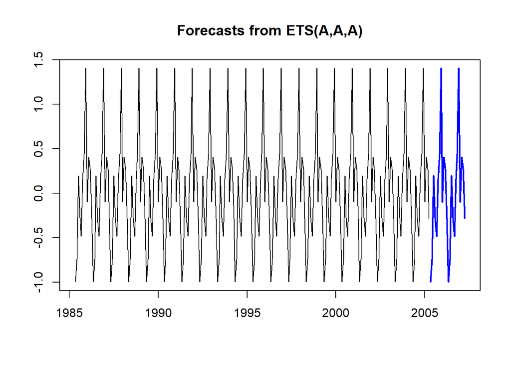

```r
plot(forecast(fitSeasonalETS, h=24))
```

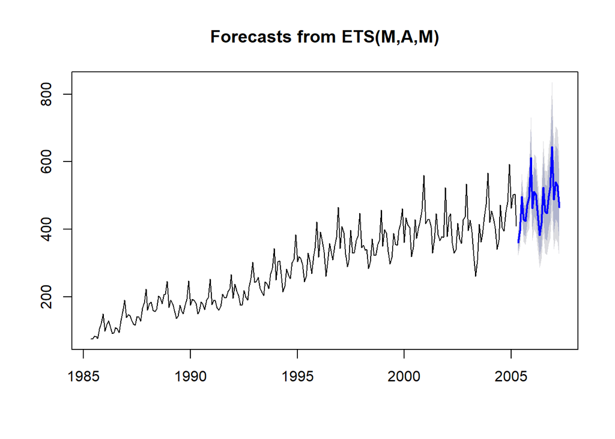

```r
plot(forecast(fitEts, h=24))
```